# Sampling Distributions Unveiled

5/11/2020

```r
library(mosaic)
library(tidyverse)
library(car)
library(pander)
```

## Sampling Distributions

A sampling distribution is a necessary part in calculating a p-value, as will be discussed later. A sampling distribution can be examined [here](http://onlinestatbook.com/stat_sim/sampling_dist/). In this simulation, a population is presented, and when the simulation is put into motion, a sample from the population of size ‘n’ is plotted on the second plot, and then a subsequent point is plotted on the third plot, being the average of the ‘n’ amount of points from the second plot.

```r
N <- 512
storage <- rep(NA, N)



for (i in 1:N){
  storage[i] <- 2*i

}
```

### My Own Simulation

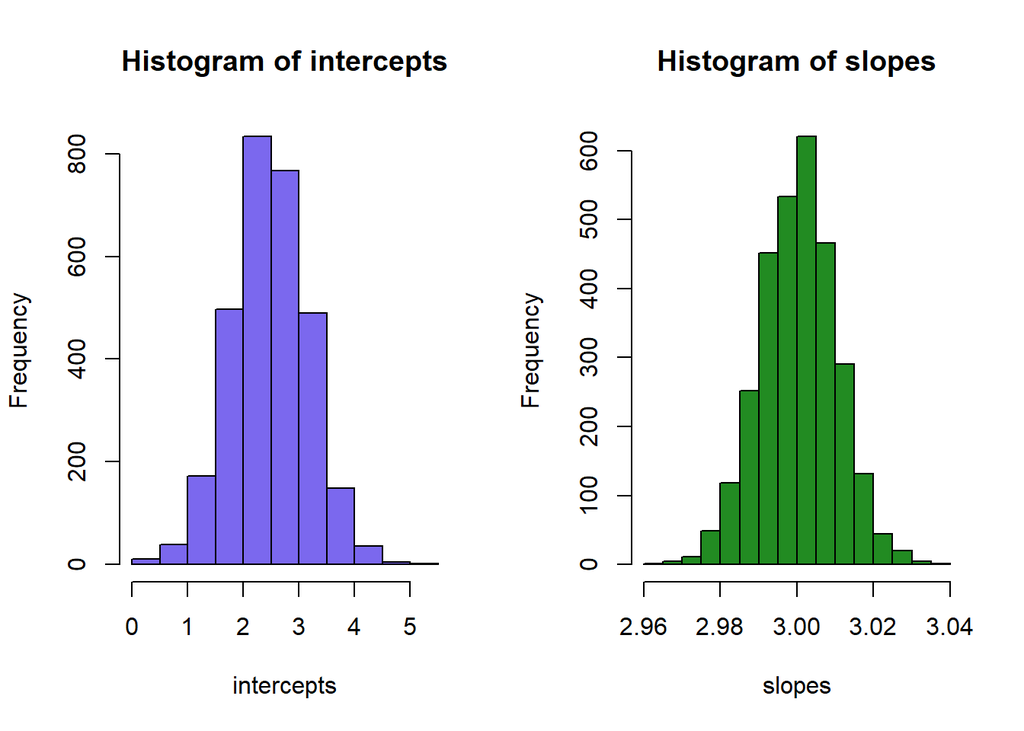

```r
N <- 3000
intercepts <- rep(NA,N)
slopes <- rep(NA,N)

n <- 30

Xi <- rep(seq(30, 100, length.out=n/2), each=2)

for (i in 1:N){
Yi <- 2.5 + 3*Xi + rnorm(n, 0, 1.2)
mylm <- lm(Yi ~ Xi)
  intercepts[i] <- coef(mylm)[1]
  slopes[i] <- coef(mylm)[2]
}


par(mfrow = c(1,2))

hist(intercepts, col = "mediumslateblue")
hist(slopes, col = "forestgreen")
```

### Standard Error

A standard error is the amount of varibility we could see in Y. The intercept and slope standard errors measure how much the y intercepts or slope would deviate if we were to take many samples from the population, as we did in the above simulation.

```r
#qt(1- 0.05/2, df) #t*
```

## P-Values

The definition of a p-value is the probability of obtaining a test statistic more extreme than the one obtained, assuming the null hypothesis is true. A useful demonstration of the p-value can be found [here](http://byuimath.com/apps/normprobwitht.html). In this applet, the p-value corresponds to the area that is shaded, given a specific t-distribution (based on the degrees of freedom in the test) and a t-value, which is discussed in the confidence interval section. When the summary of a regression is ran, the p-value is quickly computed and displayed, ready for interpretation. I will demonstrate how to compute the p-value using the standard error.

The function pt() is used, which stands for percentile. The t-value and degrees of freedom are needed. The standard error is used to find the quartile, or t-value. The t-value for an estimate can be computed using the following formula:

$$t = \frac{b_0 - \overbrace{0}^\text{a number}}{s_{b_0}}$$
Where $b_0$ is the desired estimate for which we want the quartile, and $s_{b_0}$ is the standard error of that estimate.

```r
pander(-17.5791/6.7584) #Standard error subtracted from the estimate
```

*-2.601*

```r
pander(pt(-2.601, 48)*2) #p-value of the intercept estimate
```

*0.01232*

You can see that the computed p-value does correspond with the p-value of the summary:

```r
car.lm <- lm(dist ~ speed, data = cars)
summary(car.lm) %>% pander()
```

|  | Estimate | Std. Error | t value | Pr(>\|t\|) |
| --- | --- | --- | --- | --- |
| **(Intercept)** | -17.58 | 6.758 | -2.601 | 0.01232 |
| **speed** | 3.932 | 0.4155 | 9.464 | 1.49e-12 |

Fitting linear model: dist ~ speed

| Observations | Residual Std. Error | $R^2$ | Adjusted $R^2$ |
| --- | --- | --- | --- |
| 50 | 15.38 | 0.6511 | 0.6438 |

The p-value is crucial to statistics because it measure the probability of the obtained test statistic being $t$ amount of standard erros away from the sample mean, where $t=\text{the test statistic}$.

## Confidence Intervals

A confidence interval for a given parameter, either $\beta_0$ or $\beta_1$ can be comupted with the following equations:

$$b_0 \pm t^*_{n-2}\cdot s_{b_0}$$

$$b_1 \pm t^*_{n-2}\cdot s_{b_1}$$
Where $b_0$ and $b_1$ are sample statistics obtained from just one sample of the population. This is different from the simulation demonstrating sampling distributions, where an ‘N’ amount of samples were computed. The estimates were then created by averaging all of the sample estimates. With a confidence interval, a single value of $b_0$ or $b_1$ is computed, and then a critical value multiplied by the standard error of it’s respective estimate is added and subtracted to the estimate, obtaining the upper and lower bounds of the estimate. The critical value is also known as $t^*_{n-2}$ and represents the amount of standard errors the estimate is away from the hypothesized value of the parameter, or the alternative hypothesis.

A confidence interval can be computed one of two ways, both of which will be demonstrated. Code_folding has been enabled in order to view the code that produces each result.

A regression has been run using the cars data set, using the speed of the vehicle to predict the stopping distance. A plot has also been included.

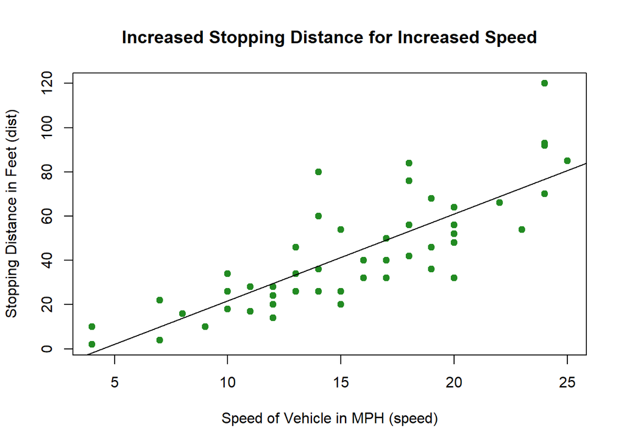

```r
View(cars)
plot(dist ~ speed, data = cars, pch = 19, col = "forestgreen", xlab = "Speed of Vehicle in MPH (speed)", ylab = "Stopping Distance in Feet (dist)", main = "Increased Stopping Distance for Increased Speed")
abline(car.lm)
```

```r
confint(car.lm) %>% pander(caption = "95% Confidence Interval for Cars Regression")
```

95% Confidence Interval for Cars Regression

|  | 2.5 % | 97.5 % |
| --- | --- | --- |
| **(Intercept)** | -31.17 | -3.99 |
| **speed** | 3.097 | 4.768 |

The more involved way to compute a confidence interval requires knowing the standard error and the quartile of the desired confidence interval. To find the quartile, we run the following code:

```r
qt(c(0.025, 0.975),48) %>% pander()
```

*-2.011* and *2.011*

Where $0.025=\frac{\alpha}{2}$ and $48=\text{Degrees of Freedom for the regression}$. These values measure the amount of standard errors between the estimate and the quartile for which 95% of the data will be contained. If we then multiply that by the standard error for our respective estimates, and then add/subtract them from the estimate itself, we have found the upper and lower bounds of our confidence interval. The estimates and the standard error can be found in the summary of the regression:

```r
summary(car.lm) %>% pander(caption = "Summary of the Cars Regression")
```

|  | Estimate | Std. Error | t value | Pr(>\|t\|) |
| --- | --- | --- | --- | --- |
| **(Intercept)** | -17.58 | 6.758 | -2.601 | 0.01232 |
| **speed** | 3.932 | 0.4155 | 9.464 | 1.49e-12 |

Summary of the Cars Regression

| Observations | Residual Std. Error | $R^2$ | Adjusted $R^2$ |
| --- | --- | --- | --- |
| 50 | 15.38 | 0.6511 | 0.6438 |

The upper and lower bounds of a 95% confidence interval for the true y-intercept, $\beta_0$, and the true regression line slope, $\beta_1$ are computed below:

```r
pander(-17.58 + qt(c(0.025, 0.975),48)*6.758)
```

*-31.17* and *-3.992*

```r
pander(3.9324 + qt(c(0.025, 0.975),48)*0.4155)
```

*3.097* and *4.768*

A simple truth and way to state your conclusion using a confidence interval is that 95% of all 95% confidence intervals contain the truth. This could be the true mean, the true y-intercept, or the true slope, depending on what your confidence interval is for, but it is always for the truth. This relates to our sampling distributions in the idea that 95% of the sample means computed will be within one standard deviation of the mean of all possible samples.